# Command Line Interface, Git and GitHub

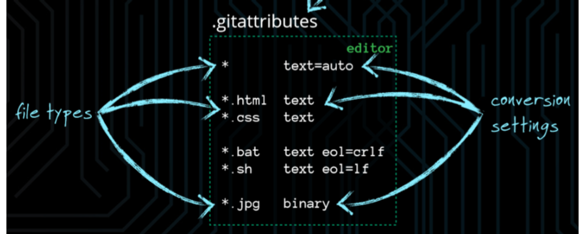

- **Cherry-picking**
  - Copy one or two commits to the current branch (E.g. from development branch to production one) when there are many commits. Will change the commit SHA
  - `git cherry-pick <abbreviated commit SHA>`: after checking out to the right branch (the one we want to copy to), copy the specified commit to the branch
    - `git cherry-pick --edit <abbreviated commit SHA>`: lets you edit the commit message via editor
  - `git cherry-pick --no-commit <ab. commit1 SHA> <ab. commit2 SHA>`: cherry-pick and combine two commits. Pulls in changes and stages them, but doesn’t commit!
    - `git commit -m <"message">`: commit the changes. Now we cherry-picked the changes from two commits and made a single commit
  - `git cherry-pick -x <ab. SHA>`: *-x* adds source SHA to commit message. When we want to track which commit we cherry-picked from. Only useful with public branches; don’t use for local branches as people don’t have access to your local branch
  - `git cherry-pick --signoff <ab. SHA>`: *–signo???* adds current user’s name to commit message. When we want to track who cherry-picked the commit along with the original committer
- **Submodules - share libraries**
  - *Bad ways of sharing libraries*
    - Copy the libraries into the projects: library quickly gets outdated as you might make changes locally on a project but can’t push them easily to update rest of projects
    - Post libraries on a central server: can’t make library changes without a project to test it in
  - *Submodules: A Git repo inside a Git repo* (way to easily share libraries accross projects)
    - Pull down updates easily
    - Test your changes with an actual dependent project
    - Share changes easily
    - History independent of containing repo

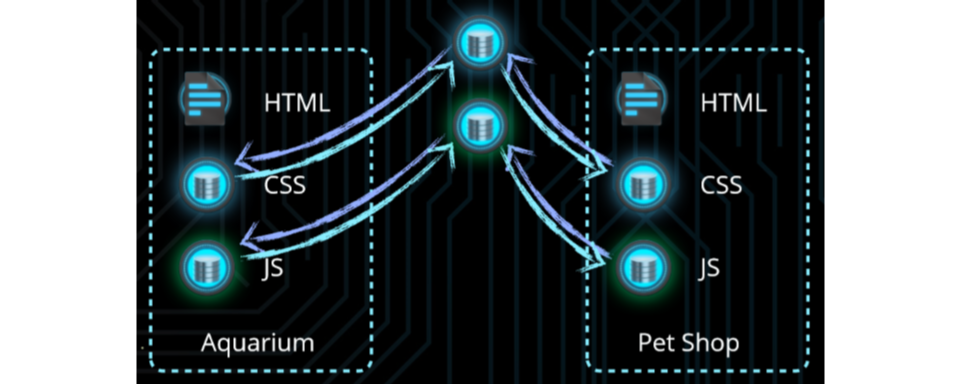

- **Adding a submodule to a project**
  1. Create a Git repo (can be down on GitHub)
  2. `git submodule add <git repo address containing submodule>`: before, go to the project that will use the submodule and type command. Will clone the project into a directory (called as git repo cloned) inside current repo (it created a submodule file: *.gitmodules*)
  3. `git add .`: stage changes
  4. `git commit -m <"message">` and `git push`
- **Gitmodules file configuration**

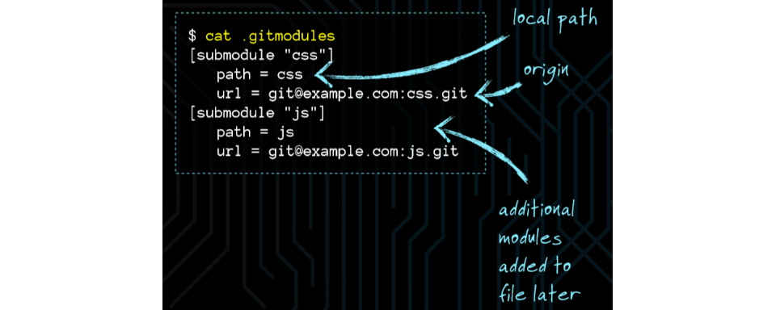

- **Modify a submodule**
  1. `cd <submodule>` and `git checkout master` (submodule don’t start out on a branch)
  2. Make changes to your files, commit and push
  3. Update parent directory: `cd ..` `git add <submodule>`, commit and push
     - `git push --recurse-submodules=check`: abort a push if you haven’t pushed a submodule (if you ran from the parent directory)
     - `git push --recurse-submodules=on-demand`: push all repositories (even submodules). No worries about the steps.
- **Cloning projects with submodule**
  1. `git clone git@example.com:<git repo address containing submodule>`: get project files, .gitmodules file and submodules that are empty directories
  2. `git submodule init`: to get the submodules, we need to initialize them. Git reads the .gitmodules ???le and adds an entry to local config (./git/config) for each submodule
  3. `git submodule update`: for each submodule, it clones the repo and check out the commit speci???ed by the parent project. Now your submodules have files
- **Submodules update** (retrieve changes that someone else has pushed)
  - `git submodule update`: from the parent projects, retrieves the submodule’s file updates
- **Restoring commits**
  - `git reflog`: Git keeps a *reflog* (second log, only in local repo) with all commits log: SHA, reflog shortname, commit info
  - `git reset --hard <ab. commit SHA>`: restore the commit
    - `git reset --harh <reflog commit shortname>`: alternative
- **Restoring branches**
  - `git log --walk-reflogs`: see reflog info in full log format
  - `git branch <new branch> <most recent commit from the deleted branch>`: create new branch and points it at the specified commit, restoring the deleted branch
    - `git branch <new branch> <reflog commit shortname>`: alternative